# Regression Model - Course Proj.

thecapacity

February 22, 2015

### Summary

Using a linear regression model, based on the `mtcars` dataset provided by R, our model found that a car with manual transmission is more effieicnt per gallon than a car with automatic transmission ( `24.39` vs. `17.15`). This estimate, that `am` represents two distinct populations, was validated with a `p.value` of `0.0014`. It was also discovered that the weight (`wt`) also plays an importat role as well. We only superficially explored interactions across variables. Based on an assumption ‘power’ indicators may be correlated with `wt` weight, such as `cyl` or engine shape `vs`, the potential exists for further exploration, including whether `hp` or `disp`is a better predictor than `cyl`.

### Analysis

I am interested in exploring the relationship between a set of variables and and an efficiency outcome, in miles per gallon (MPG), in the cars data collected. **We are particularly interested in the following two questions:**

1. *Is an automatic or manual transmission better for MPG?* - **Answer: `Manual`**
2. *Quantify the MPG difference between automatic and manual transmissions.* - **Answer: `7.24`**

#### Approach

*Note: Pre-processing is minimal, and is included in the markdown file - **but not shown** - to reduce overall page count.*

Based on my *‘expertise’*, I believe cylinders `cyl` would be another key factor to consider in addition to `am` type.

**Model 1:** However, we begin with the most parsimonious model then invetgiate other variables:

```r
fit1 <- lm(mpg ~ am, mtcars) #`am1` represnets a manual transmission
summary(fit1) #output hidden for pagecount
```

The model shows that `am` is significant at `0.001` level, with a `t value` of `4.106`, in influencing `mpg`. However, the `Adjusted R-squared` value is only `0.3385`, which means that the model can only predict about `33.85%` of the `mpg` variable. **Clearly some improvement is desired.** The residual deiviance (`720.9`) seems high, but **we will save more thorough review once we feel confidant in the model.**

**Model 2:** We then felt it would be useful to compare predicting `mpg` as a function of all variables:

```r
fit2 <- lm(mpg ~ . - 1, mtcars) #origin not included to make factor comparisons easier
summary(fit2) #output hidden for pagecount
```

Here we see that the estimated coefficient for `wt` of `-4.53`, with a signficance code of `0.1`, `hp` also has similar significance, but only a `-0.07` coefficient. **Also interesting, is that impact by number of cylinders seems to be counter to an expected result**, i.e. `cyl4` and `cyl8` show similar coefficients, though all `cyl` values have large margins for `Std. Error`. This impact seems counter to our intuition, and **we believe this is an important indicater for future exploration**. *In addition the `R-squared` value of `0.991` too high to be reasonable*.

**Model 3:** *Next, we used a model using `am`, `wt`, and `cyl`.* This was selected due to the factors mentioned above, excluding `hp` because of a `0.659` corrlation with `wt`, and the small coefficient mentioned earlier.

```r
fit3 <- lm(mpg ~ am + wt + cyl, mtcars)
summary(fit3) #output hidden for pagecount
```

From this model, we saw that `wt` and `cyl` were significant at `0.01` levels. **We also saw a more intuitive relationship between `mpg` and `cyl`**, specifically that mpg decreases more for `cyl8` than `cyl4`. Interestingly, `am` was not deemed significant; we assume this may be the result of an interaction between `am` likely with `wt`.

Therefore our final model contains these factors and the interaction (`wt`:`am`):

```r
fit4_final <- lm(mpg ~ am + cyl + wt + am:wt, mtcars)
summary(fit4_final) #$coef #abbreviated output for pagecount
```

```
##
## Call:
## lm(formula = mpg ~ am + cyl + wt + am:wt, data = mtcars)
##
## Residuals:
##     Min      1Q  Median      3Q     Max
## -3.5409 -1.5377 -0.6783  1.3160  5.2831
##
## Coefficients:
##             Estimate Std. Error t value Pr(>|t|)
## (Intercept)   29.775      2.840  10.483 7.87e-11 ***
## am1           11.569      4.088   2.830  0.00885 **
## cyl6          -2.710      1.357  -1.996  0.05647 .
## cyl8          -4.776      1.556  -3.070  0.00496 **
## wt            -2.399      0.844  -2.842  0.00860 **
## am1:wt        -4.068      1.397  -2.911  0.00730 **
## ---
## Signif. codes:  0 '***' 0.001 '**' 0.01 '*' 0.05 '.' 0.1 ' ' 1
##
## Residual standard error: 2.304 on 26 degrees of freedom
## Multiple R-squared:  0.8775, Adjusted R-squared:  0.8539
## F-statistic: 37.23 on 5 and 26 DF,  p-value: 4.743e-11
```

The appendix plots support the expected residual behavior. There is no consistent *“Residuals vs Fitted”* pattern, and the *“Normal Q-Q”* plot shows points close along the line, suggesting normal distribution. The *“Scale-Location”* plot suggests a reasonable constant variance assumption and *“Residuals vs Leverage”* shows no obvious outliers. **Note:** `echo = FALSE` was added to code below to meet the requirement that the appendix only include figures.

### Appendix

#### Best Fit Plot

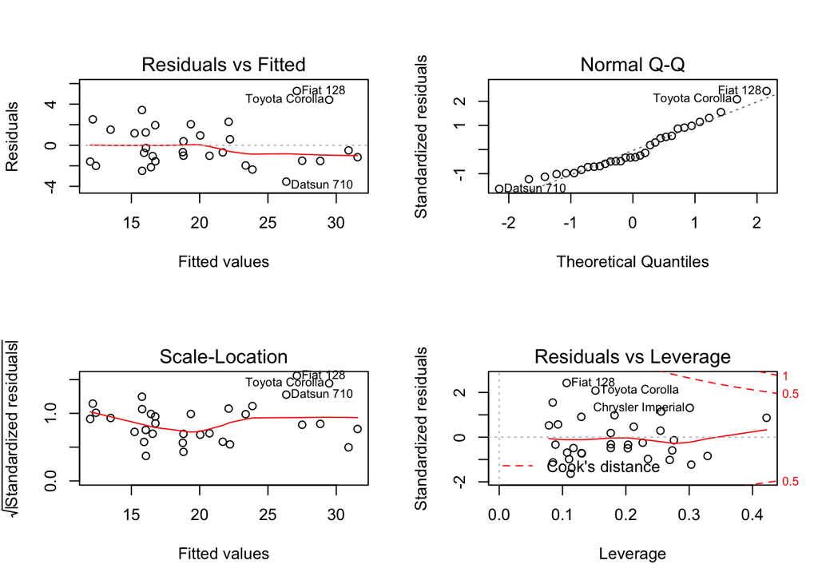

#### Residuals vs. X’s in Final Model

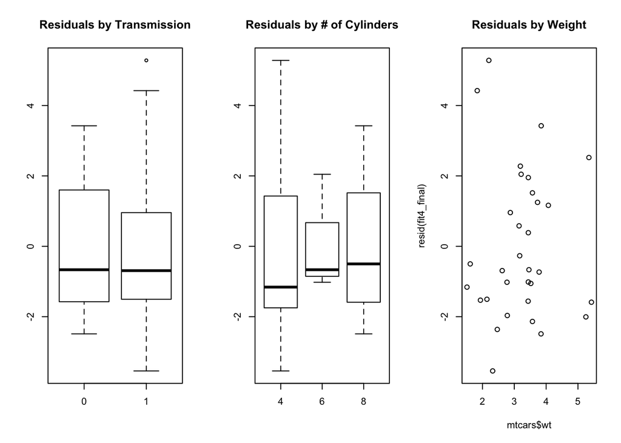

#### Plot of `mpg` vs our final key factors, `am` and `cyl`.

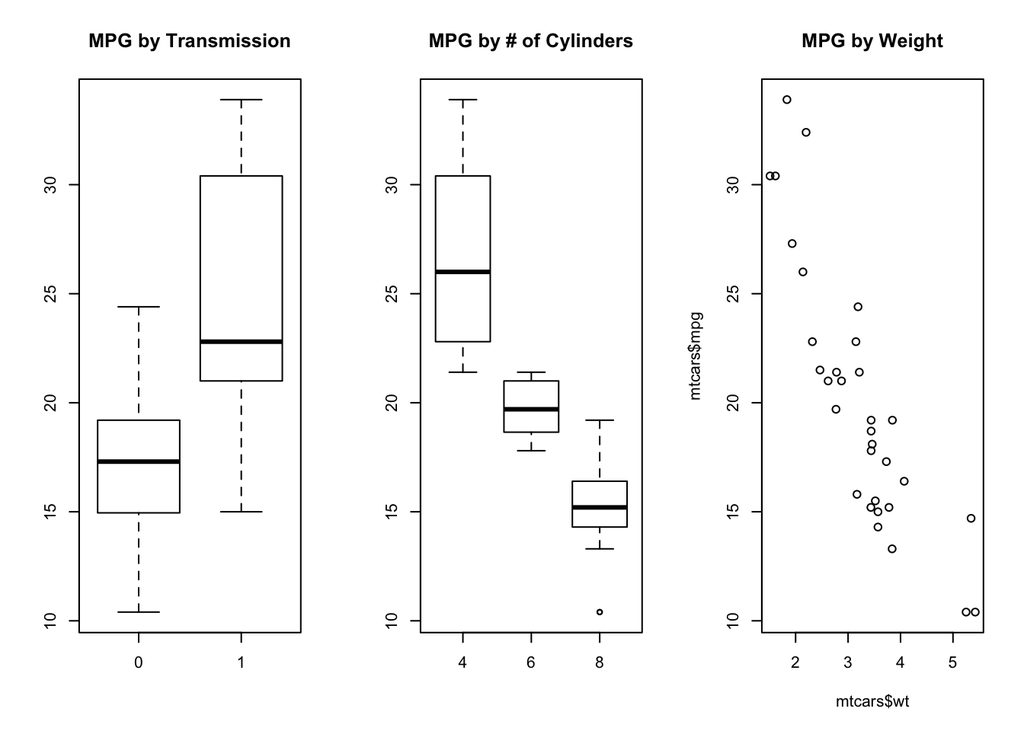